This document will show and deconstruct why negative values of the index of association can be observed in some clonal data sets.

We will use the data collected at the front of the Curry County epidemic in 2001. It is stored in the package *poppr*.

## Data Setup

```r
library("poppr")
library("igraph")
library("purrr")
library("dplyr")
library("tidyr")
library("ggplot2")
data("Pram")
epid <- Pram %>%
  setPop(~SOURCE) %>%
  popsub(blacklist = "Nursery") %>%
  setPop(~YEAR) %>%
  popsub(sublist = "2001")
```

## Index of association results

The results are negative for the full and clone-corrected data.

```
         Ia        p.Ia       rbarD        p.rD
-0.08643653  0.88300000 -0.06765208  1.00000000
```

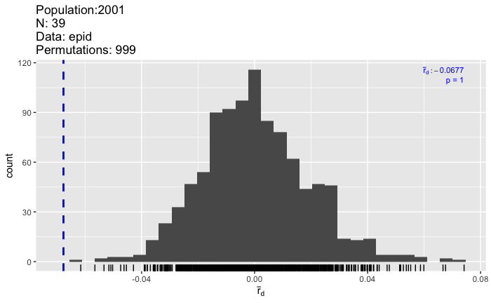

```r
ia(epid, sample = 999)
```

```
        Ia       p.Ia      rbarD       p.rD
-0.3622291  0.9600000 -0.1890791  1.0000000
```

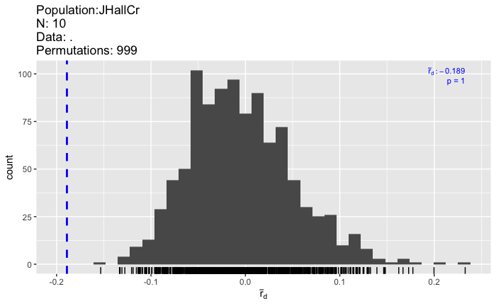

```r
epid %>% clonecorrect() %>% ia(sample = 999)
```

Note that it doesn’t change when we remove monomorphic loci:

```r
epid <- epid %>% informloci(cutoff = 1/nInd(.))
```

```
cutoff value: 2.56410256410256 % ( 1 sample ).
MAF         : 0.01

 Found 2 uninformative loci
 ============================
 2 loci found with a cutoff of 1 sample :
 PrMS6A1, Pr9C3A1
 0 loci found with MAF < 0.01
```

```r
ia(epid)
```

```
         Ia       rbarD
-0.08643653 -0.06765208
```

To get a sense of how this can be, it’s important to look at the data itself

```r
epid %>% clonecorrect() %>% genind2df(sep = "/", usepop = FALSE)
```

|  | PrMS39A1 | PrMS45A1 | PrMS43A1 |
| --- | --- | --- | --- |
| 1004.1 | 130/250 | 166/186 | 376/485 |
| 1021.1 | 130/250 | 166/186 | 372/489 |
| 1033.1 | 130/250 | 166/186 | 376/465 |
| 2092 | 130/254 | 166/186 | 376/485 |
| 2108.2 | 130/250 | 166/186 | 376/477 |
| 4088.1 | 130/250 | 166/186 | 376/489 |
| 4154 | 130/250 | 166/186 | 380/489 |
| 4167.1 | 130/250 | 166/186 | 376/493 |
| 4168.2 | 130/250 | 166/186 | 376/505 |
| 1020.1 | 130/250 | 166/166 | 376/485 |

It’s clear that there is not much variation except for at a single locus. When we take a look at the locus statistics, we can see that they are quite skewed.

```r
locus_table(epid)
```

```
allele = Number of observed alleles
1-D = Simpson index
Hexp = Nei's 1978 gene diversity
------------------------------------------
```

```
          summary
locus      allele  1-D Hexp Evenness
  PrMS39A1   3.00 0.51 0.52     0.94
  PrMS45A1   2.00 0.50 0.51     1.00
  PrMS43A1   9.00 0.62 0.63     0.68
  mean       4.67 0.54 0.55     0.87
```

How does this lack of diversity affect the index of association? Since it is measured from variation between genetic distances, where the expected variation is calculated as the sum of the variation across all loci, we will investigate what the distance distributions look like.